**A Study of AQI, Temperature and Precipitation around Indian Metropolitan.**

by Srinivasan V - 2024MCS120020

**Objective:**

The programming language R is a high-level, interpretive language that is primarily used for statistical computing and graphics.

It is widely used by data scientists, analysts, and researchers for tasks such as data visualization, regression analysis, time series analysis, and machine learning.

In this MiniProject, we will analyse a few rudimentary ways we can harness the power of R programming.

We will be showcasing the R’s Data Engineering and Data Visualization capabilities by cleaning and engineering the following Libraries & DataSets.

```r
library(readr)
library(tidyr)
library(dplyr)
library(ggplot2)
library(leaflet)
library(lubridate)

city_day <- read_csv("https://raw.githubusercontent.com/Demon-SrinivasanV/IIIT-K_Materials/refs/heads/main/DSC513/Mini%20Project/Datasets/Air_Quality/city_day.csv")
city_hour <- read_csv("https://raw.githubusercontent.com/Demon-SrinivasanV/IIIT-K_Materials/refs/heads/main/DSC513/Mini%20Project/Datasets/Air_Quality/city_hour.csv")
station_day <- read_csv("https://raw.githubusercontent.com/Demon-SrinivasanV/IIIT-K_Materials/refs/heads/main/DSC513/Mini%20Project/Datasets/Air_Quality/station_day.csv")
stations <- read_csv("https://raw.githubusercontent.com/Demon-SrinivasanV/IIIT-K_Materials/refs/heads/main/DSC513/Mini%20Project/Datasets/Air_Quality/stations.csv")

BLR <- read_csv("https://raw.githubusercontent.com/Demon-SrinivasanV/IIIT-K_Materials/refs/heads/main/DSC513/Mini%20Project/Datasets/Temperature_And_Precipitation_Cities_IN/Bangalore_1990_2022_BangaloreCity.csv")
MAA <- read_csv("https://raw.githubusercontent.com/Demon-SrinivasanV/IIIT-K_Materials/refs/heads/main/DSC513/Mini%20Project/Datasets/Temperature_And_Precipitation_Cities_IN/Chennai_1990_2022_Madras.csv")
DEL <- read_csv("https://raw.githubusercontent.com/Demon-SrinivasanV/IIIT-K_Materials/refs/heads/main/DSC513/Mini%20Project/Datasets/Temperature_And_Precipitation_Cities_IN/Delhi_NCR_1990_2022_Safdarjung.csv")
LKO <- read_csv("https://raw.githubusercontent.com/Demon-SrinivasanV/IIIT-K_Materials/refs/heads/main/DSC513/Mini%20Project/Datasets/Temperature_And_Precipitation_Cities_IN/Lucknow_1990_2022.csv")
BOM <- read_csv("https://raw.githubusercontent.com/Demon-SrinivasanV/IIIT-K_Materials/refs/heads/main/DSC513/Mini%20Project/Datasets/Temperature_And_Precipitation_Cities_IN/Mumbai_1990_2022_Santacruz.csv")
JDH <- read_csv("https://raw.githubusercontent.com/Demon-SrinivasanV/IIIT-K_Materials/refs/heads/main/DSC513/Mini%20Project/Datasets/Temperature_And_Precipitation_Cities_IN/Rajasthan_1990_2022_Jodhpur.csv")
BBI <- read_csv("https://raw.githubusercontent.com/Demon-SrinivasanV/IIIT-K_Materials/refs/heads/main/DSC513/Mini%20Project/Datasets/Temperature_And_Precipitation_Cities_IN/weather_Bhubhneshwar_1990_2022.csv")
GEOLOC <- read_csv("https://raw.githubusercontent.com/Demon-SrinivasanV/IIIT-K_Materials/refs/heads/main/DSC513/Mini%20Project/Datasets/Temperature_And_Precipitation_Cities_IN/Station_GeoLocation_Longitute_Latitude_Elevation_EPSG_4326.csv")
MARSH <- read_csv("https://raw.githubusercontent.com/Demon-SrinivasanV/IIIT-K_Materials/refs/heads/main/DSC513/Mini%20Project/Datasets/Marshland_Data/pallikaranai.csv")
MAA_Station_GPS <- read.csv("https://raw.githubusercontent.com/Demon-SrinivasanV/IIIT-K_Materials/refs/heads/main/DSC513/Mini%20Project/Datasets/Air_Quality/MAA_Station_GeoLoc.csv")
```

From the Initialized DataSets, we will try to extrapolate tangible and concise information about the Air Quality Indexes [AQI], Temperature & Precipitation of multiple Metropolitan Cities in India and their variance and impact over the decades, more precisely, between 1990 to 2022.

We will also look at the impact these factors have had on Avian Species in and around a once flourishing wetlands ecosystem, home to migratory species from across the world.

Here are the Proposed Objectives for consideration:

**1. Interactive Metropolitan City Map**

**2. AQI Distribution by City [2015 - 2020]**

**3. Total Precipitation per Month by City [2021]**

**4. Monthly Temperature Distribution Across Cities [2021]**

**5. AQI during Diwali [2015 - 2019]**

**6. Interactive AQI Stations Map in Chennai**

**7. Month-wise Precipitation in Chennai [1990 - 2022]**

**8. Monthly Temperature Distribution Chennai [1990 & 2021]**

**9. AQI Bucket Distribution for Chennai [2015 - 2022]**

**10. Pallikaranai Marshland Avian Population**

**Preliminary Analysis:**

In Preliminary Analysis, we will be taking a look at the DataSets and a High-Level Reasoning for the Data Cleansing & Data Massaging to Extract Impactful Information:

- Assessment of the City specific DataSets needs granularity in Date for extracting and disseminating context-specific Information efficiently, hence we are extracting the [YEAR] and [MONTH] into separate columns.
- Setting up Colour Palettes for different data points enables better Human-Readable Information from the Deluge of Raw Data.
- Pre-Processing and Pre-Filtering Raw data makes it more malliable to work with to produce Information,while costing minimal processing overhead.

```r
# Extracting Month and Year from Time for better processing
datasets <- list("MAA", "BLR", "DEL", "LKO", "BOM", "JDH", "BBI")

# Adding 2 extra columns [MONTH] & [YEAR] to the City Dataset for making filtering easier.
for (dataset in datasets)
  {
  assign(dataset, get(dataset) %>%
           mutate(
             time = as.Date(time, format = "%d-%m-%Y"),
             month = format(time, "%b"),
             year = as.numeric(format(time, "%Y"))
           )
        )
  }

city_day <- city_day %>%
  mutate(year = lubridate::year(Date))

# Create a color palette
color_palette <- c(
  "Bengaluru" = "#FF0000",
  "Bangalore" = "#FF0000",
  "Chennai" = "#0000FF",
  "Delhi" = "#00FF00",
  "Lucknow" = "#FFFF00",
  "Mumbai" = "#FF7F00"
)

# Define colors for AQI_Bucket categories
aqi_colors <- c(
  "Good" = "lightgreen",
  "Satisfactory" = "yellow",
  "Moderate" = "orange",
  "Poor" = "red",
  "Very Poor" = "purple",
  "Severe" = "maroon"
)

# Define a vector of custom colors for each year
prcp_colors <- c(
  "#FF0000", "#FF0044", "#FF0088", "#FF00CC", "#FF00FF",
  "#FF4400", "#FF4444", "#FF4488", "#FF44CC", "#FF44FF",
  "#FF8800", "#FF8844", "#FF8888", "#FF88CC", "#FF88FF",
  "#FFCC00", "#FFCC44", "#FFCC88", "#FFCCCC", "#FFCCFF",
  "#FFFF00", "#FFFF44", "#FFFF88", "#FFFFCC", "#CCFFFF",
  "#CCFF00", "#CCFF44", "#CCFF88", "#CCFFCC", "#CC8800",
  "#CC8844", "#CC8888", "#CC88FF"
)

# Create a bird color palette
bird_color_palette <- c(
  "CORMORANTS" = "#8B0A1A",
  "DARTERS" = "#6B7FBE",
  "HERONS" = "#32CD32",
  "EGRETS" = "#964B00",
  "OPEN-BILLED-STORKS" = "#663300",
  "SPOONBILLS" = "#FF99CC",
  "WHITE-IBIS" = "#D3D3D3",
  "LITTLE-GREBE" = "#7F007F",
  "INDIAN-MOORHEN" = "#2E865F",
  "BLACK-WINGED-STILTS" = "#333333",
  "PURPLE-MOORHENS" = "#B400FF",
  "WARBLERS" = "#9AC0CD",
  "COOTS" = "#6495ED",
  "DABCHICKS" = "#8BC34A",
  "GLOSSY-IBIS" = "#C7C4C1",
  "GREY-HEADED-LAPWINGS" = "#6666FF"
)

# Filter for 2021 and add city column for each dataset
MAA_2021 <- MAA %>% filter(year == 2021) %>% mutate(city = "Chennai")
BLR_2021 <- BLR %>% filter(year == 2021) %>% mutate(city = "Bangalore")
DEL_2021 <- DEL %>% filter(year == 2021) %>% mutate(city = "Delhi")
LKO_2021 <- LKO %>% filter(year == 2021) %>% mutate(city = "Lucknow")
BOM_2021 <- BOM %>% filter(year == 2021) %>% mutate(city = "Mumbai")

# Combine all datasets into IND
IND <- bind_rows(MAA_2021, BLR_2021, DEL_2021, LKO_2021, BOM_2021)

# Filtering out Chennai AQI Stations
MAA_Stations <- stations %>%
  filter(StationId %in% c("TN001", "TN002", "TN003", "TN004"))

# Filtering out values pertaining to Chennai's AQI
MAA_AQI_Day <- city_day %>%
  filter(City %in% c("Chennai")) %>%
  filter(AQI_Bucket != "")

# Adding coordinates to Chennai's AQI Stations
MAA_Merged <- left_join(MAA_Stations, MAA_Station_GPS, by = "StationId")
```

**Detailed Analysis:**

**1. Interactive Metropolitan City Map:**

```r
# Create a map with markers for each city
leaflet(GEOLOC %>% filter(Location_Name %in% c("Bangalore", "Chennai", "Delhi", "Lucknow", "Mumbai")),
        options = leafletOptions(minZoom = 4, maxZoom = 5)) %>%
  addTiles() %>%
  addCircleMarkers(
    ~Longitude, ~Latitude,
    color = ~as.character(ifelse(Location_Name %in% names(color_palette), color_palette[Location_Name], "black")),
    popup = ~paste0("<b>", Location_Name, "</b><br>Elevation: ", Elevation, "</br>")
  ) %>%
  addLegend(
    colors = ~ifelse(Location_Name %in% names(color_palette), color_palette[Location_Name], "black"),
    labels = ~ifelse(Location_Name %in% names(color_palette), Location_Name, "Other"),
    opacity = 1, position = "bottomright"
  )
```

[interactive chart not shown]

We will be mainly focusing on these Metropolitan Cities and their weather track record.

**2. AQI Distribution by City [2015 - 2020]:**

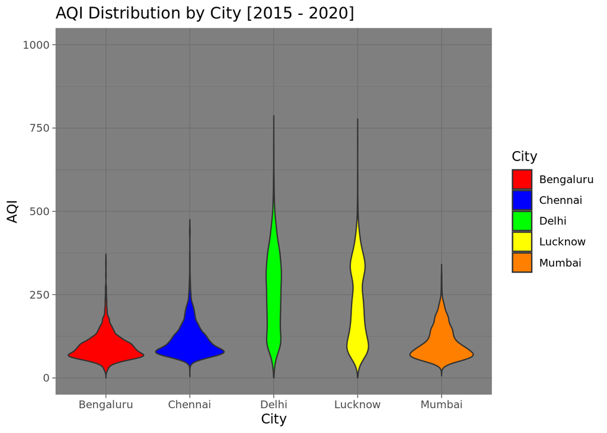

```r
# Remove records where AQI is missing
city_day_clean <- city_day %>%
  filter(!is.na(AQI) & AQI != "") %>%
  filter(City %in% c("Bengaluru", "Chennai", "Delhi", "Lucknow", "Mumbai"))

# Plot a violin graph with custom colors
ggplot(city_day_clean, aes(x = City, y = AQI, fill = City)) +
  geom_violin(trim = FALSE) +
  scale_y_continuous(limits = c(0, 1000)) +  # Set max y-axis to 1000
  scale_fill_manual(values = color_palette) +  # Use the custom color palette
  labs(title = "AQI Distribution by City [2015 - 2020]", x = "City", y = "AQI") +
  theme_dark()
```

Here we have a Violin Plot showcasing the data-spread of AQIs for each city.

**3. Total Precipitation per Month by City [2021]:**

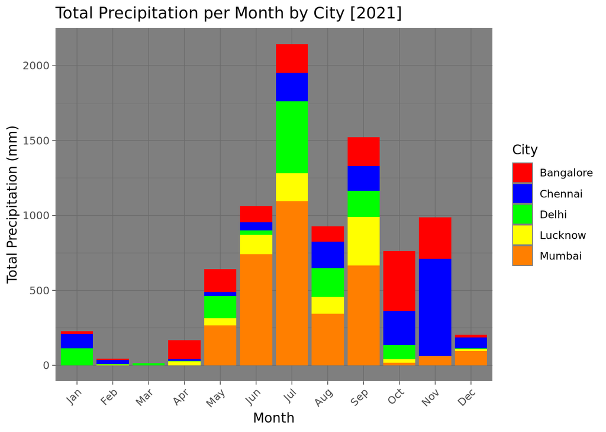

```r
# Group the data by month and city, then sum the precipitation
total_prcp_per_month <- IND %>%
  group_by(month, city) %>%
  summarise(total_prcp = sum(prcp, na.rm = TRUE)) # Remove NA values if any

# Ensure the month column is ordered
total_prcp_per_month <- total_prcp_per_month %>%
  mutate(month = factor(month, levels = c("Jan", "Feb", "Mar", "Apr", "May", "Jun",
                                          "Jul", "Aug", "Sep", "Oct", "Nov", "Dec")))

# Create the bar plot
ggplot(total_prcp_per_month, aes(x = month, y = total_prcp, fill = city)) +
  geom_bar(stat = "identity", position = "stack") + # Stack the bars by city
  scale_fill_manual(values = c(color_palette), name = "City") + # Add the color palette
  labs(
    title = "Total Precipitation per Month by City [2021]",
    x = "Month",
    y = "Total Precipitation (mm)",
    fill = "City"
  ) +
  theme_dark() +
  theme(axis.text.x = element_text(angle = 45, hjust = 1))
```

Precipitation across the Months from each City in 2021.

**4. Monthly Temperature Distribution Across Cities [2021]:**

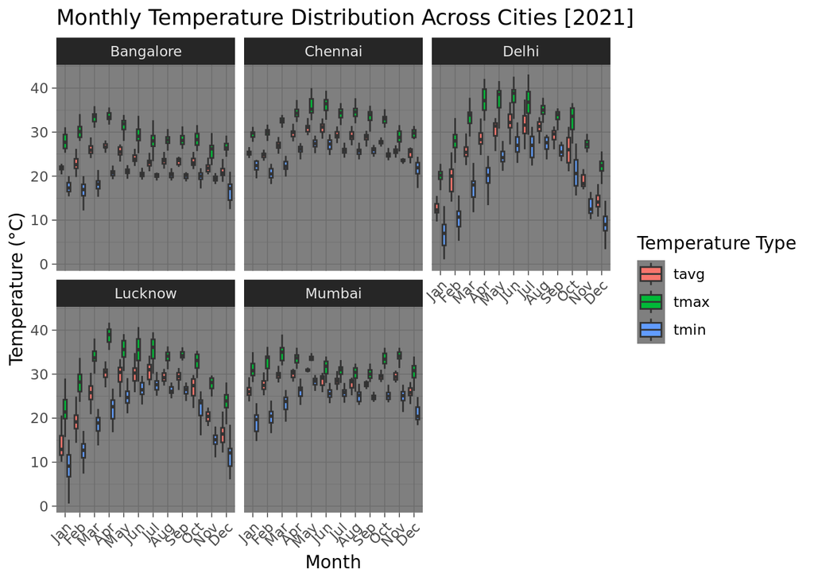

```r
# Mutate and order the data based on Month & perform pivot_longer to segregate the Tmin, Tavg, Tmax
IND_long <- IND %>%
  mutate(month = factor(month, levels = c("Jan", "Feb", "Mar", "Apr", "May",
                                            "Jun", "Jul", "Aug", "Sep", "Oct",
                                            "Nov", "Dec"))) %>%
  pivot_longer(cols = c(tmin, tavg, tmax),
               names_to = "Temperature_Type",
               values_to = "Temperature")

# Create the box plot
ggplot(IND_long, aes(x = month, y = Temperature, fill = Temperature_Type)) +
  geom_boxplot(outlier.shape = NA) +
  facet_wrap(~ city) +
  theme_dark() +
  theme(axis.text.x = element_text(angle = 45, hjust = 1)) +
  labs(
    title = "Monthly Temperature Distribution Across Cities [2021]",
    x = "Month",
    y = "Temperature (°C)",
    fill = "Temperature Type"
  )
```

An insightful look into the wild temperature differences across Metropolitans in India.

**5. AQI during Diwali [2015 - 2019]:**

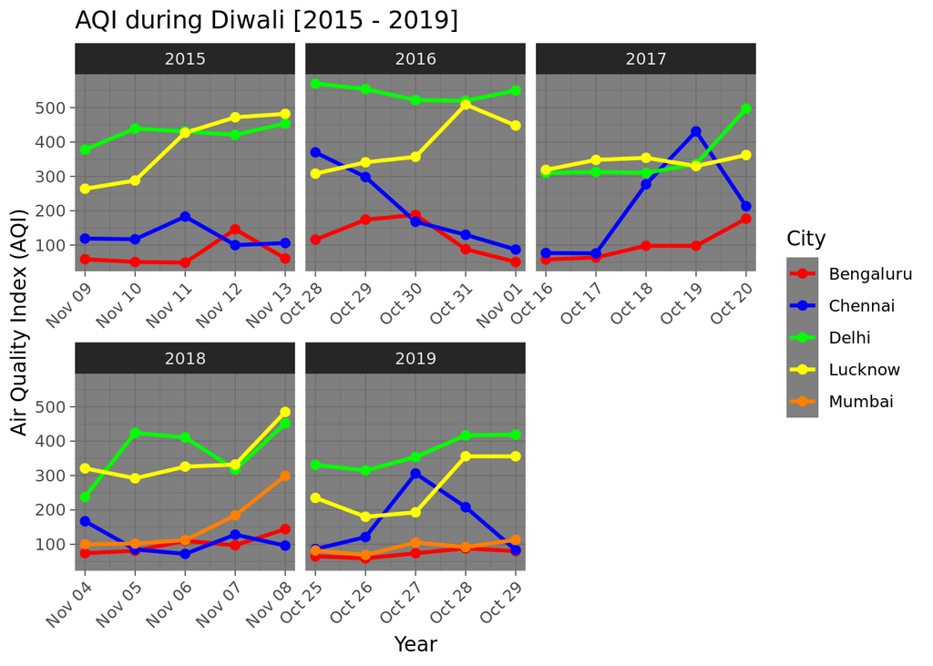

```r
# Filter the data for specific dates
city_diwali <- city_day %>%
  select(City, Date, AQI, year) %>%
  filter(Date %in% c(
    "2015-11-09", "2015-11-10", "2015-11-11", "2015-11-12", "2015-11-13",
    "2016-10-28", "2016-10-29", "2016-10-30", "2016-10-31", "2016-11-01",
    "2017-10-16", "2017-10-17", "2017-10-18", "2017-10-19", "2017-10-20",
    "2018-11-04", "2018-11-05", "2018-11-06", "2018-11-07", "2018-11-08",
    "2019-10-25", "2019-10-26", "2019-10-27", "2019-10-28", "2019-10-29"
  )) %>%
  filter(City %in% c("Bengaluru", "Chennai", "Delhi", "Lucknow", "Mumbai")) %>%
  filter(!is.na(AQI) & AQI != "")

ggplot(city_diwali, aes(x = Date, y = AQI, color = City)) +
  geom_line(size = 1) +  # Line for each City
  geom_point(size = 2) +  # Add points for clarity
  labs(
    title = "AQI during Diwali [2015 - 2019]",
    x = "Year",
    y = "Air Quality Index (AQI)",
    color = "City"
  ) +
  theme_dark() +
  theme(axis.text.x = element_text(angle = 45, hjust = 1)) +
  scale_color_manual(values = color_palette) +
  facet_wrap(~year, scales = "free_x")
```

Analysing the adverse impact of explosives-laced celebrations in every Metropolitan.

**6. Interactive AQI Stations Map in Chennai:**

```r
# Define the popup content for each station
popup_content <- paste0("<b>", MAA_Merged$StationName, "</b><br>", "Status: ", MAA_Merged$Status, "<br>")

# Create the leaflet map and add the stations
leaflet(options = leafletOptions(minZoom = 11, maxZoom = 14)) %>%
  addTiles() %>%
  addMarkers(
    data = MAA_Merged,
    lat = ~Latitude,
    lng = ~Longitude,
    popup = paste0(popup_content)
  )
```

[interactive chart not shown]

An Interactive map showing the current status of each AQI Station in Chennai.

**7. Month-wise Precipitation in Chennai [1990 - 2022]:**

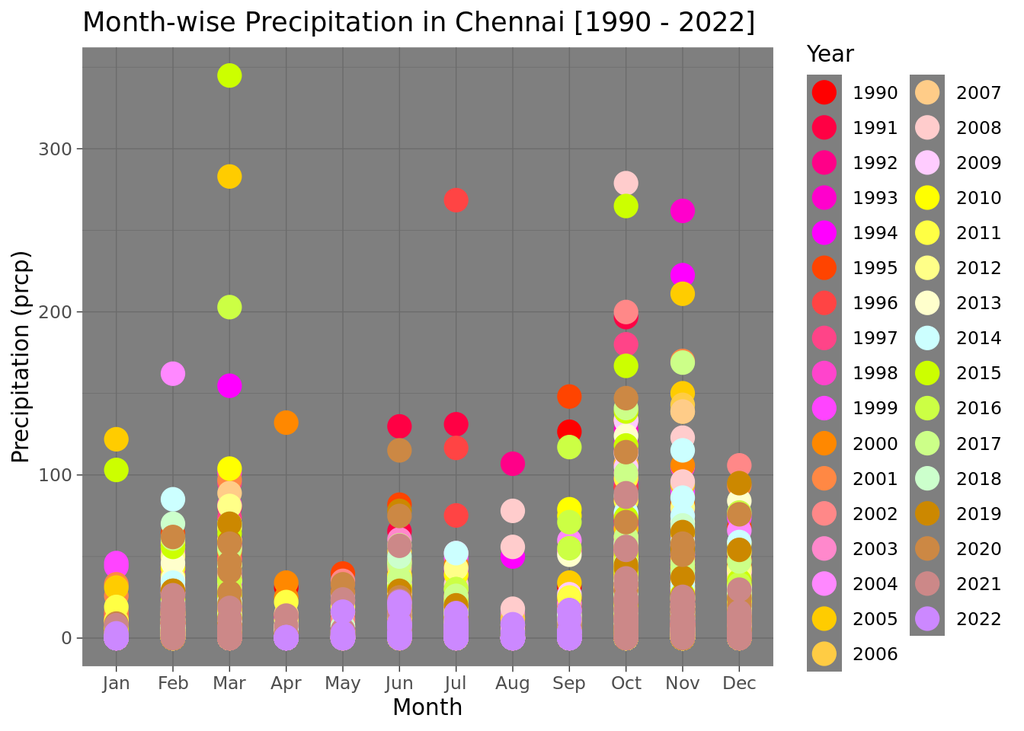

```r
# Plot the prcp value using a scatter plot with custom colors for each year
ggplot(MAA %>% filter(!is.na(prcp) & prcp != ""), aes(x = factor(month), y = prcp)) +
  geom_point(aes(color = as.factor(year)), size = 5) +
  scale_color_manual(values = prcp_colors) +
  scale_x_discrete(labels = c("Jan", "Feb", "Mar", "Apr", "May", "Jun",
                               "Jul", "Aug", "Sep", "Oct", "Nov", "Dec")) +
  labs(x = "Month", y = "Precipitation (prcp)", title = "Month-wise Precipitation in Chennai [1990 - 2022]", color = "Year") +
  theme_dark()
```

Month-wise Precipitation in Chennai giving us a strategic understanding into predicting Rainfall in that region.

**8. Monthly Temperature Distribution Chennai [1990 & 2021]:**

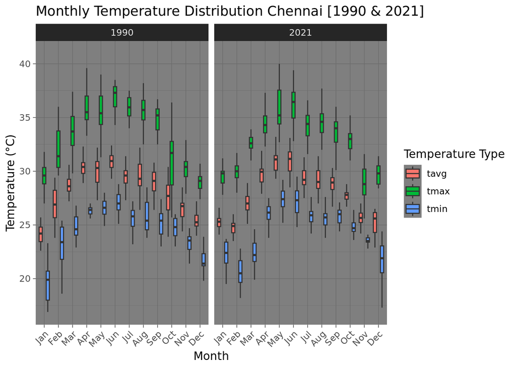

```r
# Mutate and order the data based on Month & perform pivot_longer to segregate the Tmin, Tavg, Tmax
MAA_long <- MAA %>%
  mutate(month = factor(month, levels = c("Jan", "Feb", "Mar", "Apr", "May",
                                            "Jun", "Jul", "Aug", "Sep", "Oct",
                                            "Nov", "Dec"))) %>%
  pivot_longer(cols = c(tmin, tavg, tmax),
               names_to = "Temperature_Type",
               values_to = "Temperature")

# Create the box plot for Chennai
ggplot(MAA_long %>% filter(year %in% c("1990", "2021")), aes(x = month, y = Temperature, fill = Temperature_Type)) +
  geom_boxplot(outlier.shape = NA) +  # Hide outliers for cleaner visuals
  facet_wrap(~year) +
  theme_dark() +
  theme(axis.text.x = element_text(angle = 45, hjust = 1)) +
  labs(
    title = "Monthly Temperature Distribution Chennai [1990 & 2021]",
    x = "Month",
    y = "Temperature (°C)",
    fill = "Temperature Type"
  )
```

A monthly boxplot detailing the Tmin, Tavg and Tmax of the year [1990] and [2021].

**9. AQI Bucket Distribution for Chennai [2015 - 2022]:**

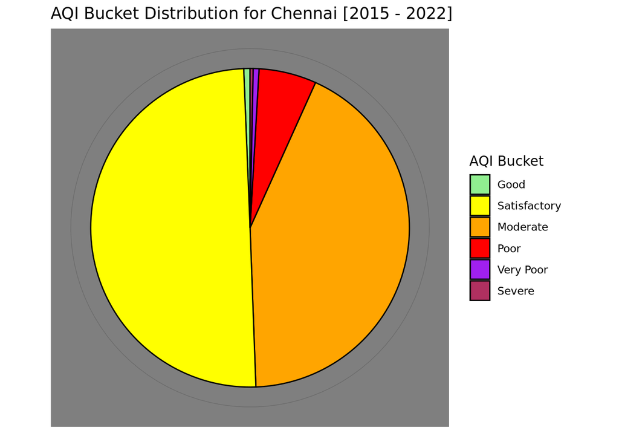

```r
# Count the occurrences of each AQI_Bucket
aqi_counts <- MAA_AQI_Day %>%
  count(AQI_Bucket) %>%
  mutate(percentage = n / sum(n) * 100)

# Define the order of AQI_Bucket
aqi_order <- c("Good", "Satisfactory", "Moderate", "Poor", "Very Poor", "Severe")

# Ensure the AQI_Bucket is in the correct order
aqi_counts$AQI_Bucket <- factor(aqi_counts$AQI_Bucket, levels = aqi_order)

# Create the pie chart
ggplot(aqi_counts, aes(x = "", y = percentage, fill = AQI_Bucket)) +
  geom_bar(stat = "identity", width = 1, color = "#000000") +
  coord_polar(theta = "y") +
  scale_fill_manual(values = aqi_colors) +
  scale_x_discrete(NULL, breaks = NULL) +
  scale_y_continuous(NULL, breaks = NULL) +
  theme_dark() +
  labs(title = "AQI Bucket Distribution for Chennai [2015 - 2022]") +
  theme(legend.position = "right") +
  guides(fill = guide_legend(title = "AQI Bucket"))
```

An insightful Pie-Chart showcasing the AQI of Chennai during the majority of it’s time between [2015] to [2022].